# SOM analysis (PCA to SOM)

Dustin Kincaid

4/28/2020

Variable names and abbreviations

| variable | abbrev |
| --- | --- |
| site | site |
| event_start | event_start |
| season | season |
| rain_event_total_mm | r_e_mm |
| rain_event_hrs | r_e_hrs |
| rain_int_mmPERmin_max | r_e_intMax |
| rain_int_mmPERmin_mean | r_e_intMean |
| rain_preEvent_1d | r_pre1d |
| rain_preEvent_7d | r_pre7d |
| rain_preEvent_14d | r_pre14d |

[output cut: 27 more lines]

```r
# Create df's with and without response variables (i.e., NO3_kg_km2, SRP_kg_km2, event_NO3_SRP)
# Site: Hungerford Brook
hf_with <- hford %>%
  select_if(is.numeric) %>%
  # Use complete cases only
  na.omit()
hf_without <- hf_with %>%
  select(-c(NO3, SRP, NO3toSRP))
# Site: Wade Brook
wd_with <- wade %>%
  select_if(is.numeric) %>%
  na.omit()
wd_without <- wd_with %>%
  select(-c(NO3, SRP, NO3toSRP))

# Dimensions of df's
# Hungerford
dim(hf_with)
```

```
[1] 40 33
```

```r
# Wade
dim(wd_with)
```

```
[1] 60 33
```

Should we transform the data before doing PCA?

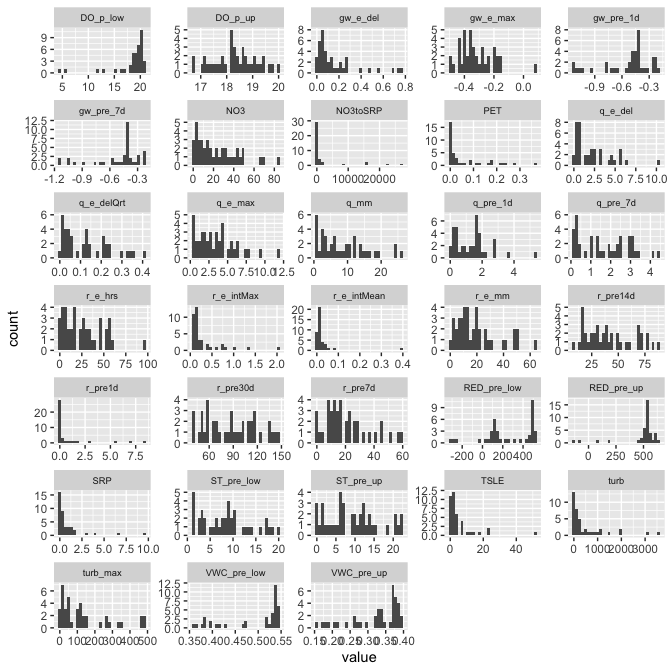

```r
# Look at histograms of data
hf_with %>%
  # Gather all columns into one long column
  pivot_longer(cols = r_e_mm:VWC_pre_low, names_to = "variable", values_to = "value") %>%
  # Plot of histograms
  ggplot(aes(x = value)) +
  facet_wrap(~variable, scales = "free", ncol = 5) +
  geom_histogram() +
  theme(strip.text = element_text(size = 7))
```

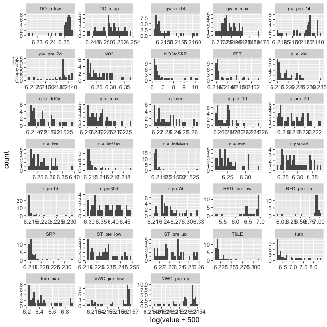

```r
# Let's log transform all variables for now
hf_with %>%
  # Here I transform the date: log(value + 500)
  mutate_all(list(~ log(. + 500))) %>%
  # Gather all columns into on long column
  pivot_longer(cols = r_e_mm:VWC_pre_low, names_to = "variable", values_to = "value") %>%
  # Plot of histograms
  ggplot(aes(x = value)) +
  facet_wrap(~variable, scales = "free", ncol = 5) +
  geom_histogram() +
  xlab("log(value + 500") +
  theme(strip.text = element_text(size = 7))
```

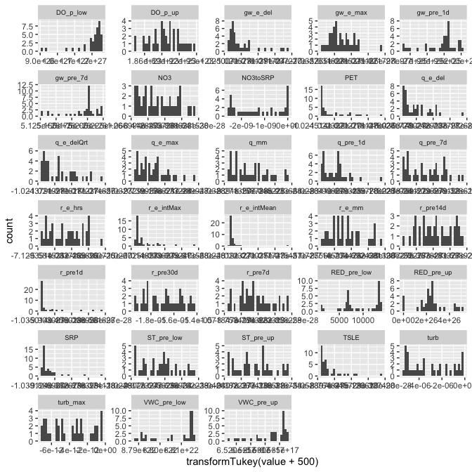

```r
# That was not really effective, let's try using the transformTukey function from the rcompanion package
# https://rcompanion.org/handbook/I_12.html
hf_with %>%
  # Apply the transformTukey function to all variables
  mutate_all(list(~ transformTukey(. + 500, plotit = FALSE, quiet = TRUE))) %>%
  pivot_longer(cols = r_e_mm:VWC_pre_low, names_to = "variable", values_to = "value") %>%
  ggplot(aes(x = value)) +
  facet_wrap(~variable, scales = "free", ncol = 5) +
  geom_histogram() +
  xlab("transformTukey(value + 500)") +
  theme(strip.text = element_text(size = 7))
```

```r
# Create dfs w/ transformed data as an option
hf_with_trans <- hf_with %>%
  # Apply the transformTukey function to all variables
  mutate_all(list(~ transformTukey(. + 500, plotit = FALSE, quiet = TRUE)))
hf_without_trans <- hf_without %>%
  mutate_all(list(~ transformTukey(. + 500, plotit = FALSE, quiet = TRUE)))
wd_with_trans <- wd_with %>%
  mutate_all(list(~ transformTukey(. + 500, plotit = FALSE, quiet = TRUE)))
wd_without_trans <- wd_without %>%
  mutate_all(list(~ transformTukey(. + 500, plotit = FALSE, quiet = TRUE)))
```

I tried using feature importance in random forests to reduce the number of variables for the SOM, but it wasn’t very effective. My question then is: how do I use PCA to reduce the number of variables/dimensionality?  
Use 1: Do I do PCA on all variables including response variables (NO3 & SRP yield & NO3 to SPR yield ratios) and somehow select variables based on how they map out in PCA space?  
Use 2: Or do I keep all predictor variables and then do PCA on them to create orthogonal variables and reduce dimensionality of the dataset such as in Pearce et al. 2011?

PCA use 1: examining how all variables map out in PCA space  
I’m also unsure exactly how to do PCA properly, so I include multiple options below

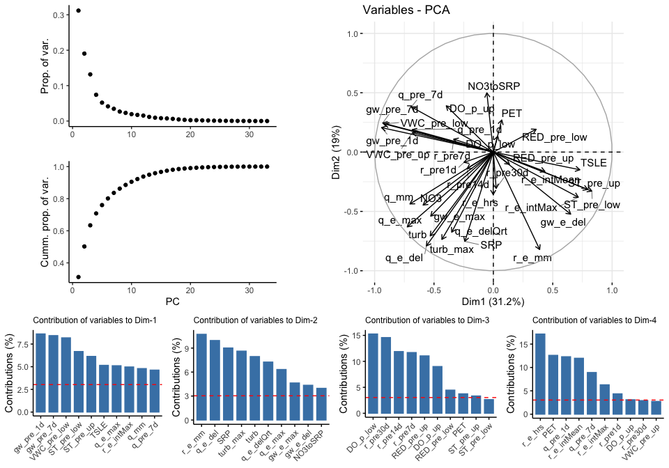

```r
# SITE = HUNGERFORD BROOK
# Including predictors (NO3 & SRP yield & NO3:SRP yield ratio); variables are NOT transformed to improve normality
# PCA on the Pearson CORRELATION matrix
# This (using the corr. matrix) seems like the proper method given untransformed (raw) data
# where variables have different units and ranges
  PC_hf_with_cor <- prcomp(hf_with, scale = TRUE)
  pcaCharts(PC_hf_with_cor)
```

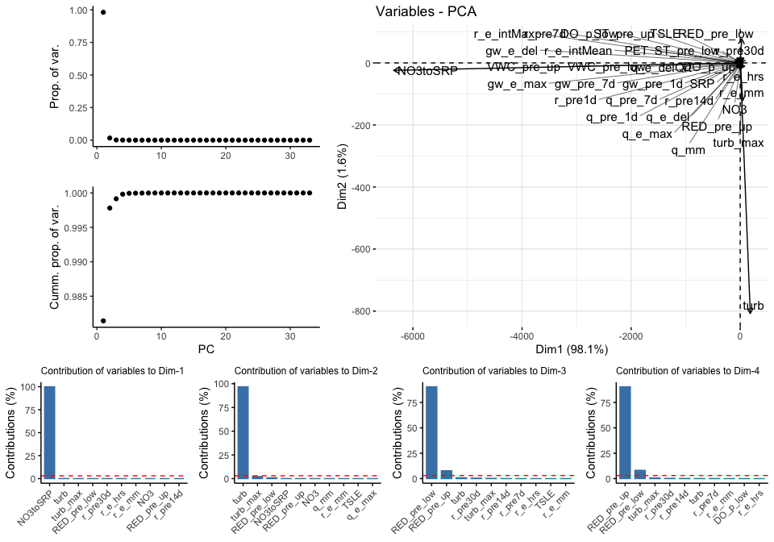

```r
# PCA on the COVARIANCE matrix
  PC_hf_with_cov <- prcomp(hf_with, scale = FALSE)
  pcaCharts(PC_hf_with_cov)
```

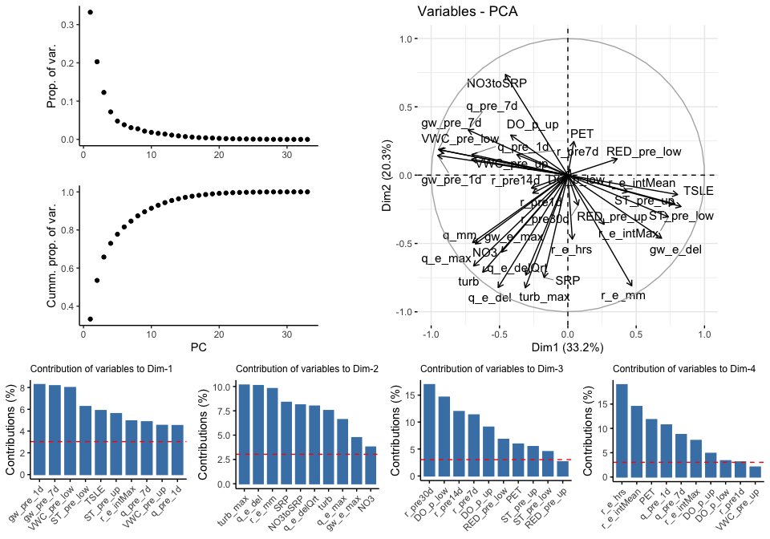

```r
# Including precitors; variables ARE transformed to improve normality
# PCA on the Pearson CORRELATION matrix
  PC_hf_with_trans_cor <- prcomp(hf_with_trans, scale = TRUE)
  pcaCharts(PC_hf_with_trans_cor)
```

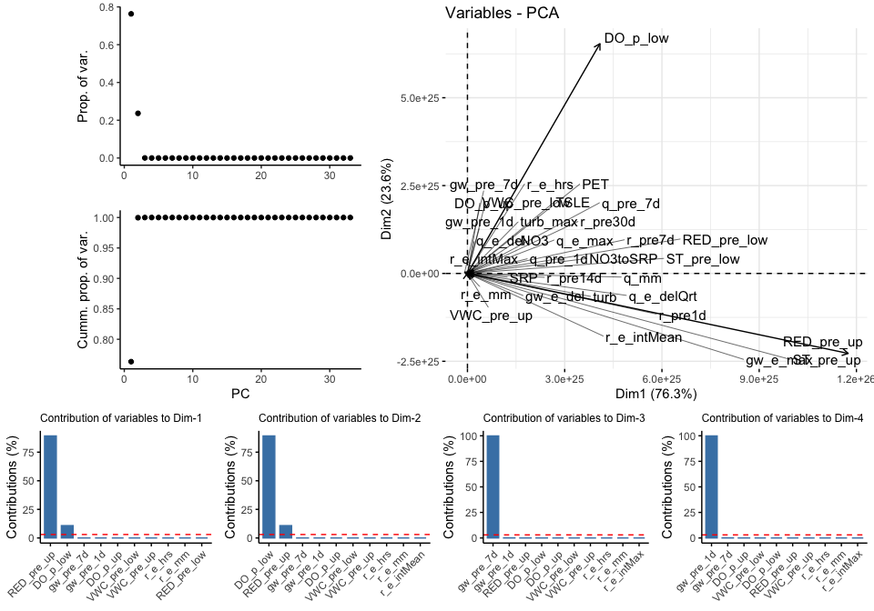

```r
# PCA on the COVARIANCE matrix
  PC_hf_with_trans_cov <- prcomp(hf_with_trans, scale = FALSE)
  pcaCharts(PC_hf_with_trans_cov)
```

I think I should probably do PCA with the correlation matrix.  
Visually the results of the PCA with untransformed vs. transformed distributions look fairly similar, though not sure how to test. Maybe stick with untransformed distributions b/c easier to explain?  
I think prcomp uses the Pearson correlation coefficient. In Pearce et al. they use the Spearman rank correlation matrix. I don’t think you can implement this using `prcomp()`, but you can do it using `princomp()`. According to this website: http://www.sthda.com/english/articles/31-principal-component-methods-in-r-practical-guide/118-principal-component-analysis-in-r-prcomp-vs-princomp/ `prcomp()` is preferred b/c it uses the singular value decomposition (SVD) vs. the spectral decomposition approach, the former having greater numerical accuracy. But! `princomp()` allows you to input whatever correlation matrix you want! Let’s try it.

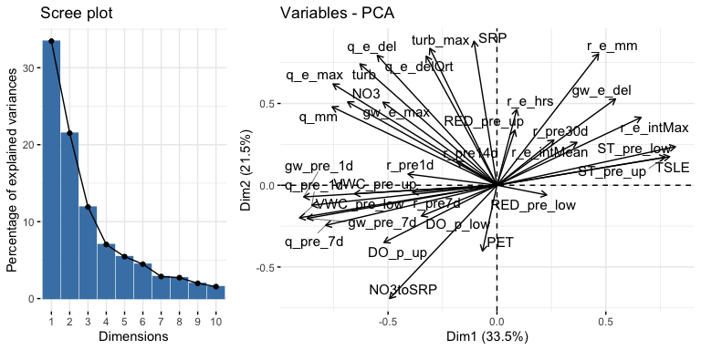

```r
corr_spearman <- cor(hf_with, method = "spearman")
PC_hf_with_cor_sp <- princomp(covmat = corr_spearman, scores = TRUE)
# get_eig(PC_hf_with_cor_sp)
# summary(PC_hf_with_cor_sp)
p1 <- factoextra::fviz_eig(PC_hf_with_cor_sp)
p2 <- factoextra::fviz_pca_var(PC_hf_with_cor_sp, repel = TRUE)
plot_grid(p1, p2, nrow = 1, rel_widths = c(1,2))
```

The results look fairly similar, except that the PCA plot is inverted. Maybe stick with `prcomp()` because it is supposed to be more numerically accurate?

PCA use 2: create orthogonal variables and reduce dimensionality of the dataset (response variables not included)

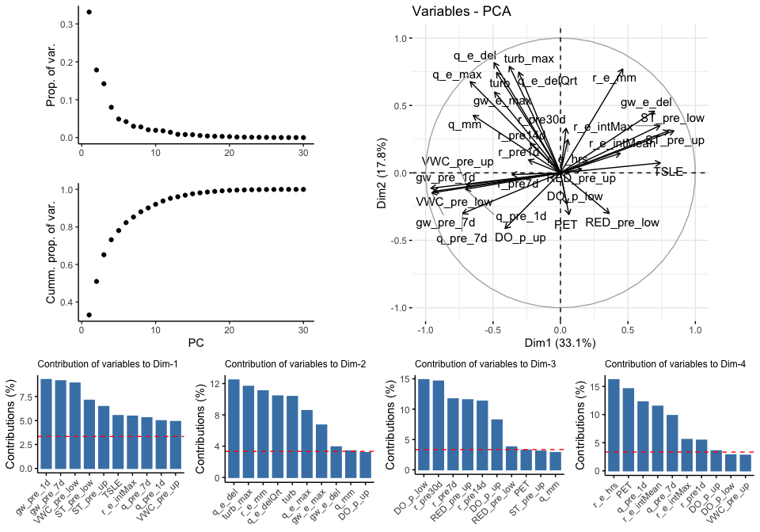

```r
# PCA on the Pearson CORRELATION matrix; variables are NOT transformed to improve normality
  PC_hf_without_cor <- prcomp(hf_without, scale = TRUE)
  pcaCharts(PC_hf_without_cor)
```

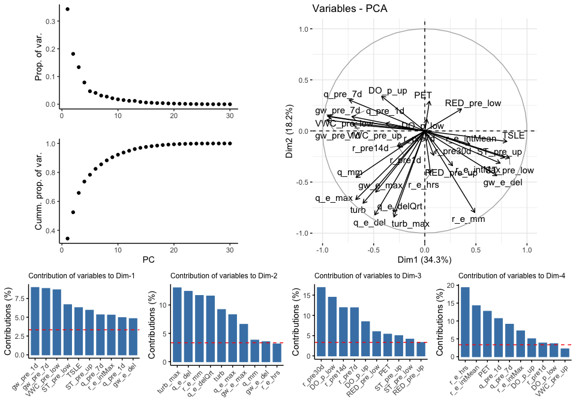

```r
# PCA on the Pearson CORRELATION matrix; variables ARE transformed to improve normality
  PC_hf_without_trans_cor <- prcomp(hf_without_trans, scale = TRUE)
  pcaCharts(PC_hf_without_trans_cor)
```

Q1: Using untransformed vs. transformed distributions results in slightly different results (visually). Which to use and how to figure that out?  
Q2: How to know how many PCs are unique/how many PCs should I keep?

Let’s move forward with PC_hf_without_cor (Hford; without predictors; Pearson correlation matrix on untransformed distributions)  
Extract and normalize b/w 0 and 1 like in Pearce et al. 2011

```r
# Output scores from PCA
hf_scores <- as_tibble(PC_hf_without_cor$x, rownames = "row_number") %>% mutate(row_number = as.integer(row_number))
# Join scores to original data & normalize each PC b/w 0 and 1
hf_PCAresuls <- full_join(hford %>% na.omit() %>% mutate(row_number = seq.int(nrow(.))),
                          hf_scores,
                          by = "row_number") %>%
  # And normalize each PC between 0 and 1
  mutate_at(vars(c(PC1:ncol(.))),
            .funs = list(~ (. - min(.)) / (max(.) - min(.))))
```

And then on to SOM? Thoughts?